# Voter Turnout by Province

Elections

Analysis

Glocal

Author

Kennedy Jokonya

Published

September 27, 2026

Elections Canada is responsible for ensuring democratic standards are met in Canadian elections. It also publishes data on past elections, including election results, voter turnout, and voter demographic characteristics. This data can be used for multiple purposes in analysing the political landscape of Canada, such as in Elections Canada’s own summary reports comparing past elections. Since the data is public, we can conduct our own analyses. This short paper uses voting data from the 45th general election in 2025 to compare turnout between two provinces of choice, and discusses how demographic differences may explain the gap.

The data used here was retrived from Statistics Canada (2026), but it can also be downloaded from Elections Canada’s web portal.

## National Turnout

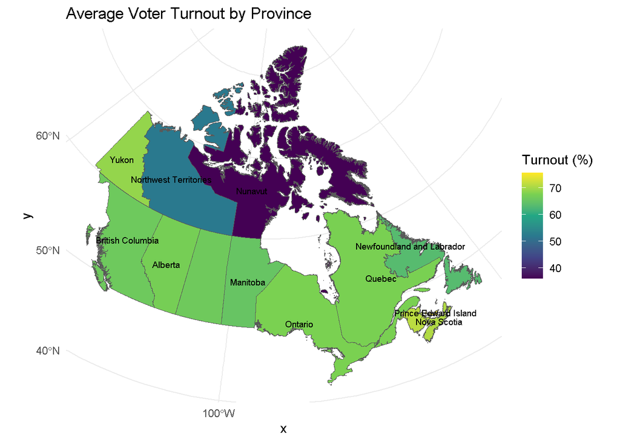

Figure 1

**What is Voter Turnout?** Voter turnout is calculated as the total number of people who cast a ballot divided by the total number of people within a province who were eligible to do so, resulting in a proportion of eligible voters who voted (Statistics Canada 2026).

Figure 1 shows average voter turnout from the 45th general election in 2025, and shows that all provinces except Northwest Territories and Nunavut had turnout greater than 50%. This means most eligible voters in nearly every province cast a ballot, with Northwest Territories and Nunavut as the exceptions. According to Elections Canada (2026), this is an improvement in the overall turnout from the previous 44th general election by `6.4` percantage points.

For our comparison, we chose British Columbia, a relatively high turnout province, to compare against Nunavut, which had the lowest turnout in this election.

## British Columbia Vs Nunavut

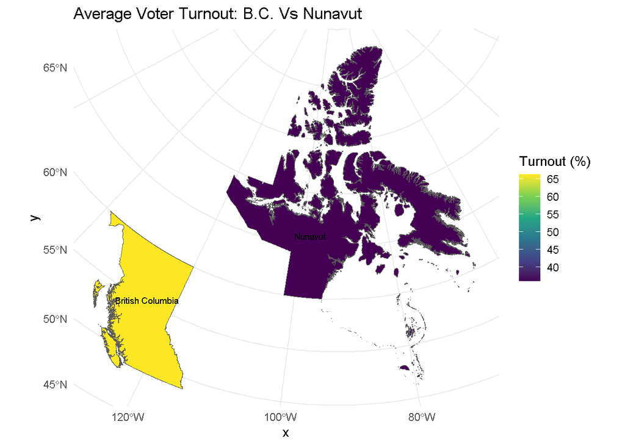

Figure 2